# Classification of Acute Respiratory Distress Syndrome

Robert Edwards

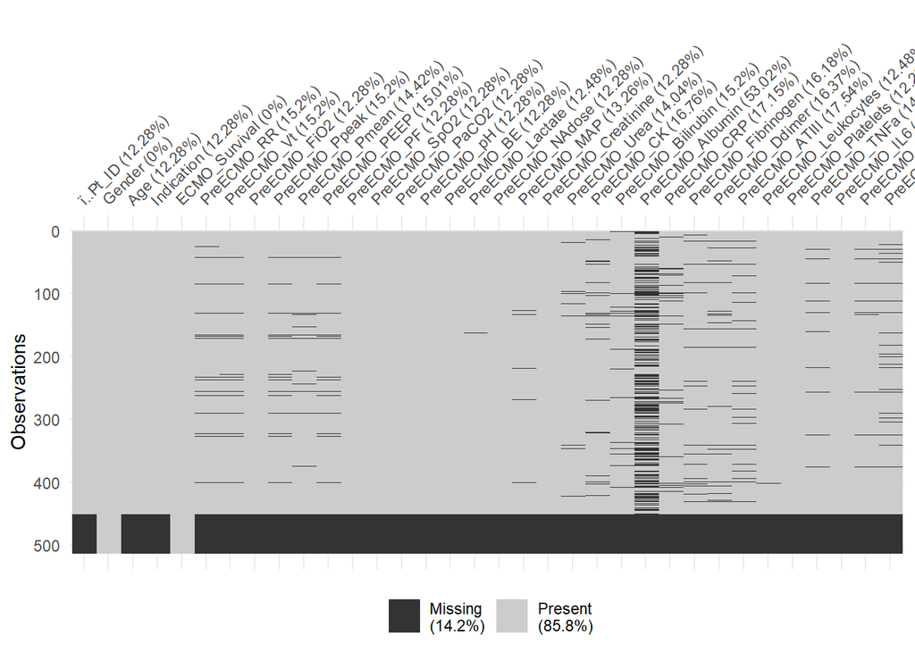

An upset plot from the `UpSetR` package can be used to visualise the patterns of missingness, or rather the combinations of missingness across cases. To see combinations of missingness and intersections of missingness amongst variables, use the `gg_miss_upset` function:

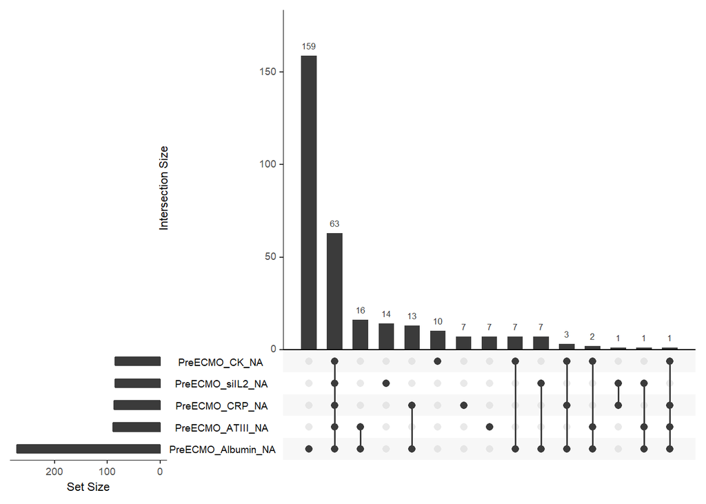

If there are 40 intersections, there will be up to 40 combinations of variables explored. The number of sets and intersections can be changed by passing arguments `nsets = 10` to look at 10 sets of variables, and nintersects = 50 to look at 50 intersections.

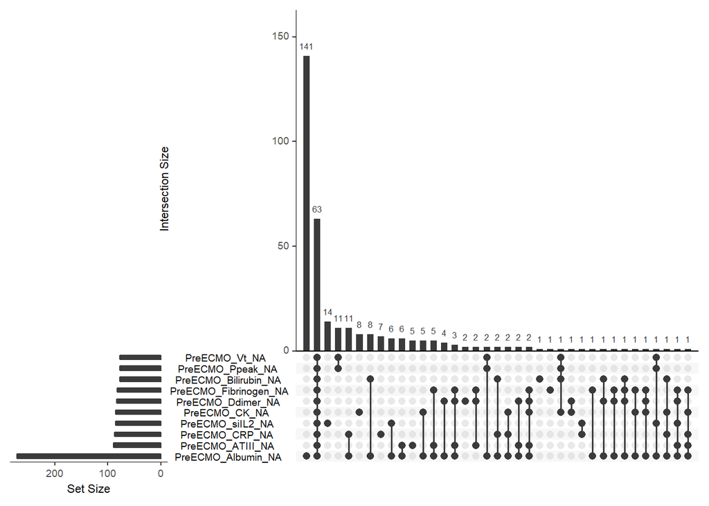

This plot shows the number of missing values in each variable in a dataset. It is powered by the `miss_var_summary()` function.

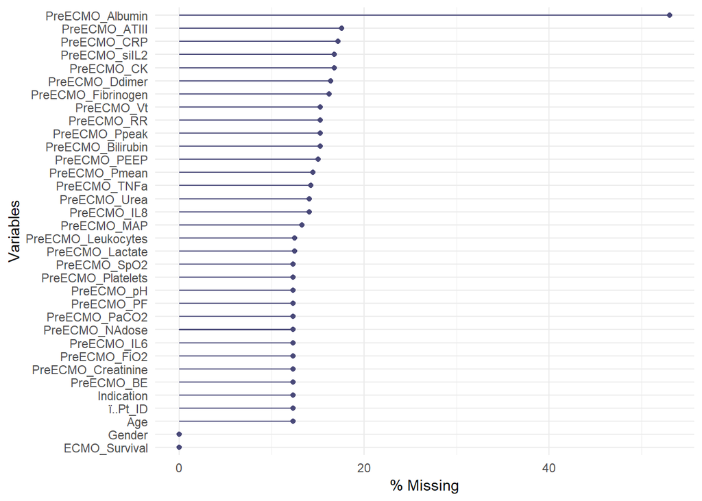

This plot shows the number of missings in each column, broken down by a categorical variable from the dataset. It is powered by a `dplyr::group_by` statement followed by `miss_var_summary()`.

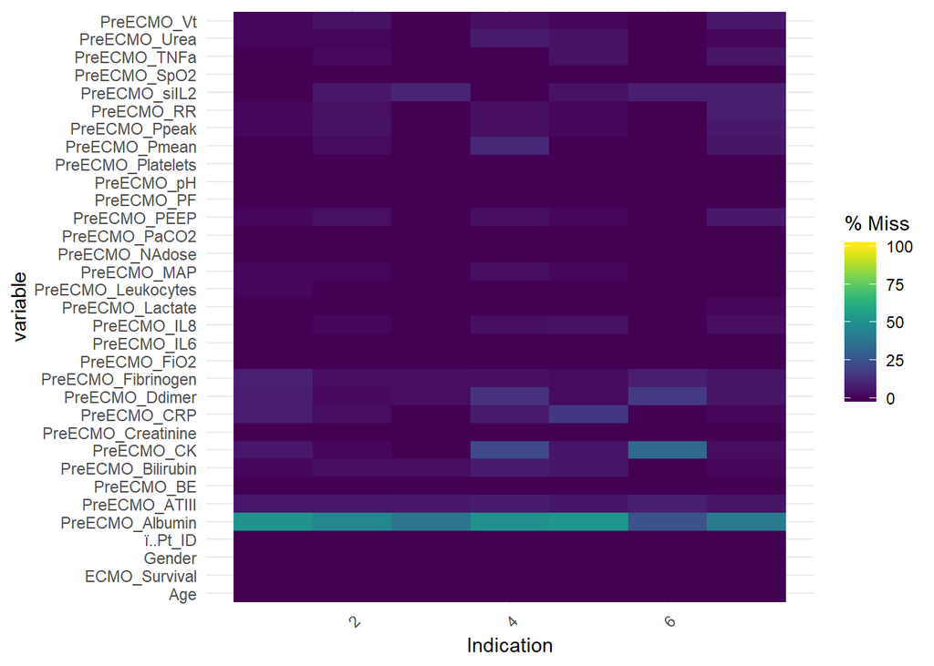

This plot shows the cumulative sum of missing values, reading the rows of the dataset from the top to bottom. It is powered by the `miss_case_cumsum()` function.

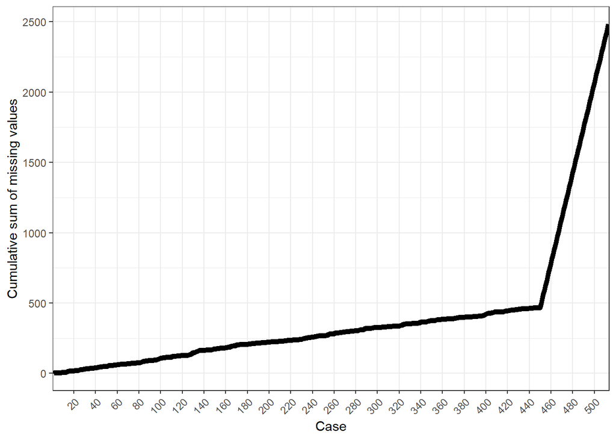

This plot shows the cumulative sum of missing values, reading columns from the left to the right of your dataframe. It is powered by the `miss_var_cumsum()` function.

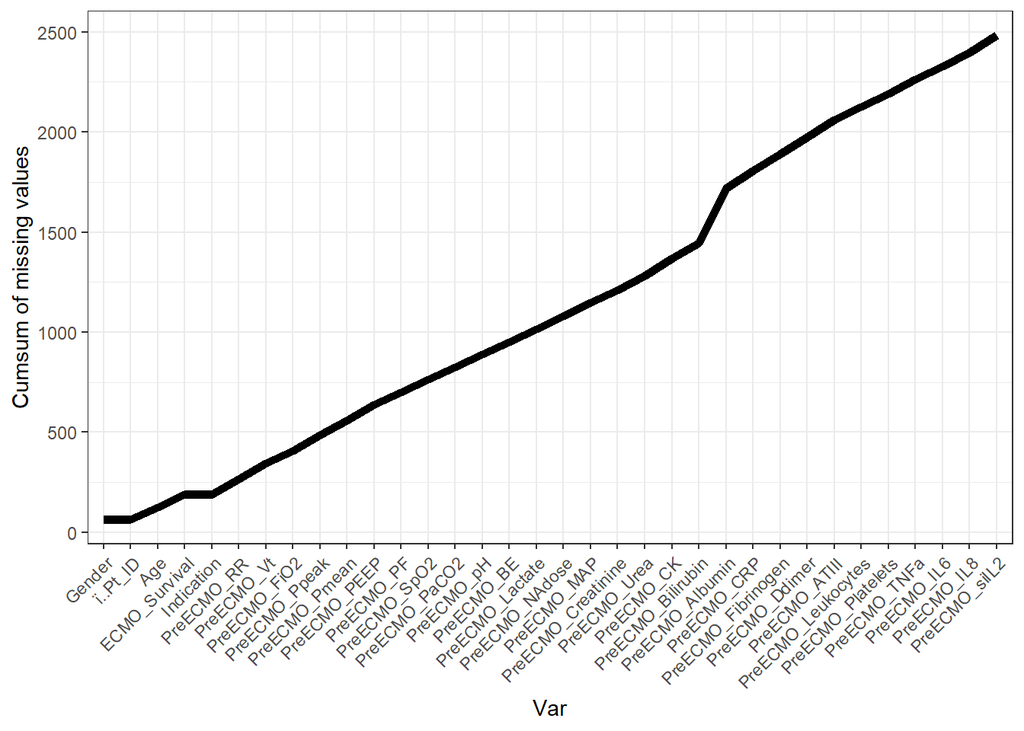

# Exploratory Data Analysis

## Boxplot

All continuous features are normally scaled to be comparable.

```
Observations: 513
Variables: 29
$ PreECMO_RR         <dbl> <matrix[25 x 1]>
$ PreECMO_Vt         <dbl> <matrix[25 x 1]>
$ PreECMO_FiO2       <dbl> <matrix[25 x 1]>
$ PreECMO_Ppeak      <dbl> <matrix[25 x 1]>
$ PreECMO_Pmean      <dbl> <matrix[25 x 1]>
$ PreECMO_PEEP       <dbl> <matrix[25 x 1]>
$ PreECMO_PF         <dbl> <matrix[25 x 1]>
$ PreECMO_SpO2       <dbl> <matrix[25 x 1]>
$ PreECMO_PaCO2      <dbl> <matrix[25 x 1]>
$ PreECMO_pH         <dbl> <matrix[25 x 1]>
$ PreECMO_BE         <dbl> <matrix[25 x 1]>
$ PreECMO_Lactate    <dbl> <matrix[25 x 1]>
$ PreECMO_NAdose     <dbl> <matrix[25 x 1]>
```

[output cut: 16 more lines]

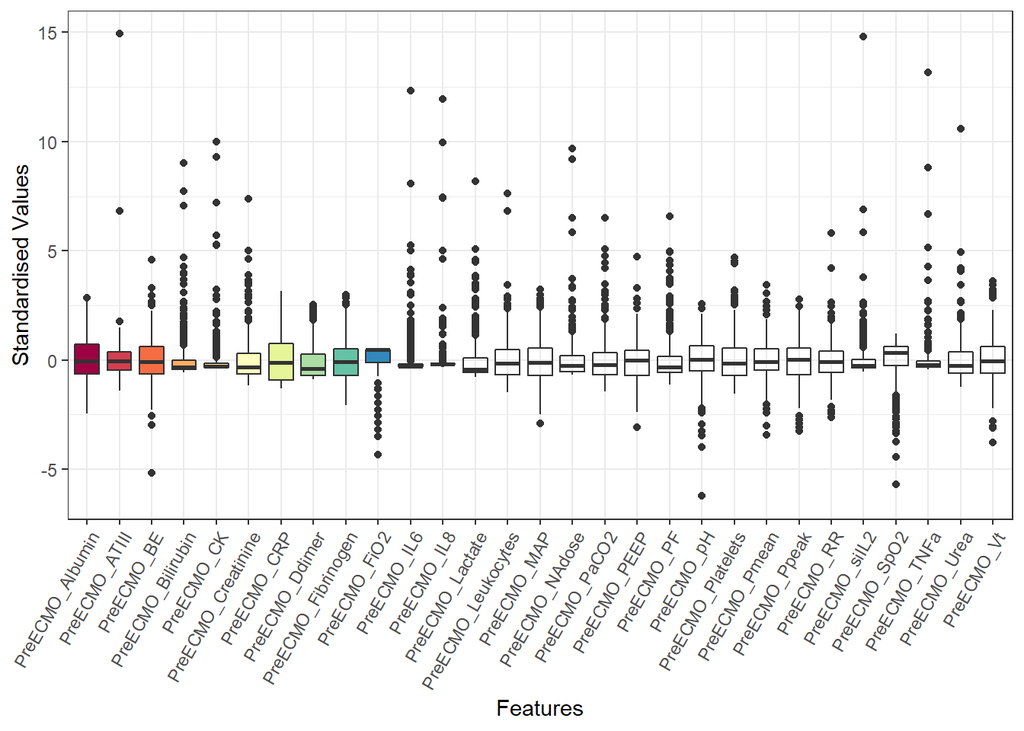

# Imputation

Here I will try various methods for data imputation.

## I. KNN Imputation

```
Observations: 513
Variables: 68
$ ï..Pt_ID               <int> 1397, 811, 1224, 1060, 1526, 653, 655, ...
$ Gender                 <fct> m, m, m, w, m, w, m, m, w, m, m, w, m, ...
$ Age                    <int> 19, 20, 22, 23, 29, 31, 34, 36, 37, 37,...
$ Indication             <int> 7, 7, 7, 7, 7, 7, 7, 7, 7, 7, 7, 7, 7, ...
$ ECMO_Survival          <fct> Y, Y, Y, Y, Y, Y, N, Y, Y, Y, Y, Y, N, ...
$ PreECMO_RR             <int> 22, 22, 15, 25, 25, 27, 34, 20, 32, 20,...
$ PreECMO_Vt             <int> 554, 560, 567, 500, 456, 443, 631, 425,...
$ PreECMO_FiO2           <dbl> 0.90, 1.00, 0.90, 0.95, 1.00, 1.00, 0.9...
$ PreECMO_Ppeak          <int> 38, 30, 35, 33, 32, 47, 31, 42, 33, 47,...
$ PreECMO_Pmean          <int> 20, 25, 22, 20, 19, 33, 22, 28, 22, 40,...
$ PreECMO_PEEP           <int> 15, 16, 15, 15, 12, 26, 13, 17, 15, 25,...
$ PreECMO_PF             <int> 82, 38, 87, 75, 51, 75, 77, 43, 42, 61,...
$ PreECMO_SpO2           <int> 92, 49, 94, 86, 72, 93, 92, 68, 63, 93,...
```

[output cut: 55 more lines]

```
Observations: 513
Variables: 30
$ PreECMO_Vt         <dbl> <matrix[25 x 1]>
$ PreECMO_FiO2       <dbl> <matrix[25 x 1]>
$ PreECMO_Ppeak      <dbl> <matrix[25 x 1]>
$ PreECMO_Pmean      <dbl> <matrix[25 x 1]>
$ PreECMO_PEEP       <dbl> <matrix[25 x 1]>
$ PreECMO_PF         <dbl> <matrix[25 x 1]>
$ PreECMO_SpO2       <dbl> <matrix[25 x 1]>
$ PreECMO_PaCO2      <dbl> <matrix[25 x 1]>
$ PreECMO_pH         <dbl> <matrix[25 x 1]>
$ PreECMO_BE         <dbl> <matrix[25 x 1]>
$ PreECMO_Lactate    <dbl> <matrix[25 x 1]>
$ PreECMO_NAdose     <dbl> <matrix[25 x 1]>
$ PreECMO_MAP        <dbl> <matrix[25 x 1]>
```

[output cut: 17 more lines]

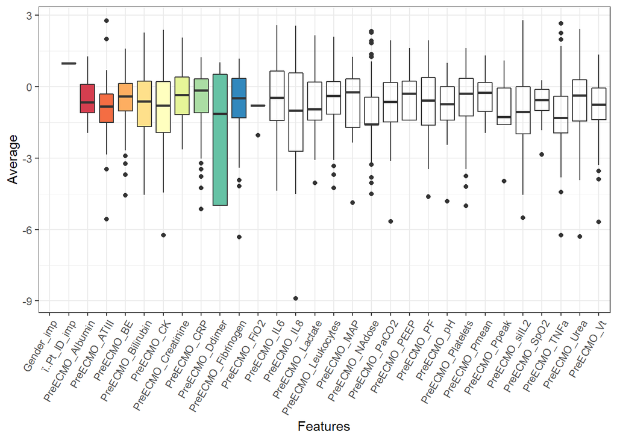

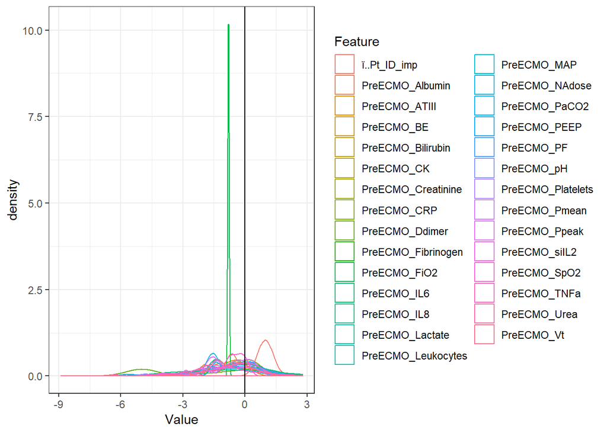

# Training/Test Data

## Dropping NAs from dataset

```
[1] 314
```

```
Call:
glm(formula = ECMO_Survival ~ ., family = binomial(link = "logit"),
    data = train.ARDS)

Deviance Residuals:
     Min        1Q    Median        3Q       Max
-3.11299   0.01256   0.20365   0.50838   1.66856

Coefficients:
                     Estimate Std. Error z value Pr(>|z|)
(Intercept)         7.459e-01  1.166e+00   0.640  0.52224
ï..Pt_ID            6.577e-04  7.042e-04   0.934  0.35031
Gender1             1.684e-01  7.360e-01   0.229  0.81908
Indication2         1.135e+00  8.017e-01   1.416  0.15689
Indication3         1.345e+00  1.307e+00   1.029  0.30354
Indication4         1.256e+00  1.655e+00   0.759  0.44776
Indication5        -1.461e+00  1.114e+00  -1.311  0.19000
Indication6         1.646e+01  1.581e+03   0.010  0.99169
Indication7         5.297e-01  1.100e+00   0.482  0.63000
Age                -1.085e+00  3.756e-01  -2.888  0.00388 **
PreECMO_RR         -2.376e-01  3.484e-01  -0.682  0.49520
PreECMO_Vt          3.141e-01  3.721e-01   0.844  0.39868
PreECMO_FiO2        3.898e-01  4.905e-01   0.795  0.42681
PreECMO_Ppeak      -1.130e+00  4.727e-01  -2.389  0.01687 *
PreECMO_Pmean       7.336e-01  6.227e-01   1.178  0.23878
PreECMO_PEEP       -1.887e-01  5.087e-01  -0.371  0.71070
PreECMO_PF          8.158e-01  5.133e-01   1.589  0.11199
PreECMO_SpO2       -2.124e+00  7.278e-01  -2.919  0.00352 **
PreECMO_PaCO2       3.202e-02  7.263e-01   0.044  0.96483
PreECMO_pH         -2.309e-01  7.183e-01  -0.321  0.74789
PreECMO_BE         -4.730e-01  5.845e-01  -0.809  0.41844
PreECMO_Lactate    -1.316e+00  5.334e-01  -2.467  0.01362 *
PreECMO_NAdose     -1.859e+00  5.764e-01  -3.226  0.00126 **
PreECMO_MAP         1.740e-01  3.096e-01   0.562  0.57412
PreECMO_Creatinine  4.600e-01  5.693e-01   0.808  0.41907
PreECMO_Urea       -1.766e-01  4.272e-01  -0.413  0.67936
PreECMO_CK          4.441e-01  4.518e-01   0.983  0.32560
PreECMO_Bilirubin   3.551e-01  4.558e-01   0.779  0.43603
PreECMO_CRP         4.630e-01  4.280e-01   1.082  0.27938
PreECMO_Fibrinogen -1.365e+00  5.002e-01  -2.728  0.00637 **
PreECMO_Ddimer     -1.467e-01  4.432e-01  -0.331  0.74073
PreECMO_ATIII      -2.063e-01  2.586e-01  -0.798  0.42493
PreECMO_Leukocytes  5.937e-01  4.333e-01   1.370  0.17069
PreECMO_Platelets  -5.491e-02  3.347e-01  -0.164  0.86969
PreECMO_TNFa        1.099e-01  2.507e-01   0.438  0.66121
PreECMO_IL6        -1.285e-01  5.114e-01  -0.251  0.80155
PreECMO_IL8         5.989e-01  5.304e-01   1.129  0.25886
PreECMO_siIL2      -2.470e-01  6.808e-01  -0.363  0.71672
---
Signif. codes:  0 '***' 0.001 '**' 0.01 '*' 0.05 '.' 0.1 ' ' 1

(Dispersion parameter for binomial family taken to be 1)

    Null deviance: 169.07  on 156  degrees of freedom
Residual deviance: 102.11  on 119  degrees of freedom
AIC: 178.11

Number of Fisher Scoring iterations: 15
```

A quick note about the plogis function: The `glm()` procedure with `family="binomial"` will build the logistic regression model on the given formula. When we use the `predict` function on this model, it will predict the log(odds) of the Y variable. This is not what we ultimately want because, the predicted values may not lie within the 0 and 1 range as expected. So, to convert it into prediction probability scores that is bound between 0 and 1, we use the `plogis()`. For more info see (blog on logisitic regression)[http://r-statistics.co/Logistic-Regression-With-R.html].

## Model Diagnostics

```
[1] 0.6923077
```

```
        0         1
0.3333333 0.8000000
```

```
[1] 0.6923077
```

```
        0         1
0.3333333 0.8000000
```

## Imputed Dataset

```
Call:
glm(formula = ECMO_Survival ~ ., family = binomial(link = "logit"),
    data = train.ARDS)

Deviance Residuals:
    Min       1Q   Median       3Q      Max
-2.8586  -0.4973   0.3646   0.7091   2.1184

Coefficients:
                    Estimate Std. Error z value Pr(>|z|)
(Intercept)        -0.060050   0.829839  -0.072 0.942313
ï..Pt_ID            0.001466   0.000497   2.949 0.003189 **
Gender1            -0.799568   0.412103  -1.940 0.052354 .
Indication2        -0.233507   0.654411  -0.357 0.721227
Indication3         0.177572   0.946911   0.188 0.851246
Indication4         1.821782   1.318526   1.382 0.167070
Indication5        -0.744931   0.771846  -0.965 0.334480
Indication6        -1.601984   1.111825  -1.441 0.149624
Indication7        -0.406773   0.852536  -0.477 0.633267
Age                -0.434630   0.221073  -1.966 0.049298 *
PreECMO_RR         -0.335603   0.256910  -1.306 0.191449
PreECMO_Vt         -0.111969   0.229660  -0.488 0.625874
PreECMO_FiO2        0.038171   0.318198   0.120 0.904515
PreECMO_Ppeak       0.098373   0.293356   0.335 0.737371
PreECMO_Pmean      -0.515321   0.343718  -1.499 0.133808
PreECMO_PEEP       -0.001138   0.292004  -0.004 0.996891
PreECMO_PF         -0.038376   0.368887  -0.104 0.917144
PreECMO_SpO2       -0.538799   0.257553  -2.092 0.036439 *
PreECMO_PaCO2       0.883239   0.494137   1.787 0.073867 .
PreECMO_pH          1.238998   0.641423   1.932 0.053404 .
PreECMO_BE         -1.029121   0.454843  -2.263 0.023661 *
PreECMO_Lactate    -0.096827   0.243589  -0.398 0.690996
PreECMO_NAdose      0.113347   0.183294   0.618 0.536320
PreECMO_MAP         0.510472   0.248319   2.056 0.039810 *
PreECMO_Creatinine -0.463896   0.289247  -1.604 0.108757
PreECMO_Urea        0.047146   0.221012   0.213 0.831078
PreECMO_CK          0.102874   0.191989   0.536 0.592075
PreECMO_Bilirubin   0.071551   0.199401   0.359 0.719722
PreECMO_CRP         0.015786   0.243725   0.065 0.948358
PreECMO_Fibrinogen  0.409629   0.280282   1.461 0.143881
PreECMO_Ddimer     -0.653350   0.178722  -3.656 0.000256 ***
PreECMO_ATIII       0.085969   0.413616   0.208 0.835349
PreECMO_Leukocytes  0.523626   0.270487   1.936 0.052884 .
PreECMO_Platelets  -0.013206   0.289883  -0.046 0.963665
PreECMO_TNFa       -0.218696   0.182107  -1.201 0.229780
PreECMO_IL6         0.217920   0.253810   0.859 0.390563
PreECMO_IL8        -0.293109   0.205400  -1.427 0.153575
PreECMO_siIL2       0.245615   0.262684   0.935 0.349778
---
Signif. codes:  0 '***' 0.001 '**' 0.01 '*' 0.05 '.' 0.1 ' ' 1

(Dispersion parameter for binomial family taken to be 1)

    Null deviance: 333.19  on 255  degrees of freedom
Residual deviance: 221.28  on 218  degrees of freedom
AIC: 297.28

Number of Fisher Scoring iterations: 5
```

## Model Diagnostics

```
[1] 0.6640625
```

```
       0        1
0.500000 0.744186
```

```
[1] 0.6640625
```

```
       0        1
0.500000 0.744186
```